# Machine Learning Project

JC Meriaux

September 27, 2015

# 1) Introduction

For this project I used the following environment

- R studio on Mac OS
- R package “CARET”
- R package “doMC”for code parallelization (registerDoMC(cores = 4);)

# 2) Data cleaning and selection

The data set was visually inspected. Columns that were not relevant (timestamp etc) or columns with mostly NA were removed. At the end of this process 43 features were selected.

Then a training set (75% of the data) and testing set (25% of the data) were created using the “createDataPartition” command.

Last, Scaling and centering pre-processing was applied, using the “preProcess” command. For each model I computed the confusion matrix (accuracy, Kappa etc.) on the test set which gives a good estimate of the out of sample error.

# 3) Model training and performance

The following approaches were done with the data set:  
* Boosted tree model (glm - stochastic gradient boosting with default parameters)  
* Boosted tree model (glm) with cross-validation  
* Random forest with default parameters

## 3.1) Boosted tree model (method=“gbm”)

The model accuracy is 0.959, with a performance summary below (confusion matrix on test set):

```
## Confusion Matrix and Statistics
##
##           Reference
## Prediction    A    B    C    D    E
##          A 1370   11    9    2    3
##          B   22  890   36    1    0
##          C    0   28  809   17    1
##          D    0    5   33  762    4
##          E    1   12    8    8  872
##
## Overall Statistics
##
##                Accuracy : 0.959
##                  95% CI : (0.9531, 0.9644)
##     No Information Rate : 0.2841
##     P-Value [Acc > NIR] : < 2.2e-16
##
##                   Kappa : 0.9482
##  Mcnemar's Test P-Value : 4.521e-06
##
## Statistics by Class:
##
##                      Class: A Class: B Class: C Class: D Class: E
## Sensitivity            0.9835   0.9408   0.9039   0.9646   0.9909
## Specificity            0.9929   0.9851   0.9885   0.9898   0.9928
## Pos Pred Value         0.9821   0.9378   0.9462   0.9478   0.9678
## Neg Pred Value         0.9934   0.9858   0.9788   0.9932   0.9980
## Prevalence             0.2841   0.1929   0.1825   0.1611   0.1794
## Detection Rate         0.2794   0.1815   0.1650   0.1554   0.1778
## Detection Prevalence   0.2845   0.1935   0.1743   0.1639   0.1837
## Balanced Accuracy      0.9882   0.9629   0.9462   0.9772   0.9919
```

Here is the model accuracy per number of bosting iteration and max tree depth.

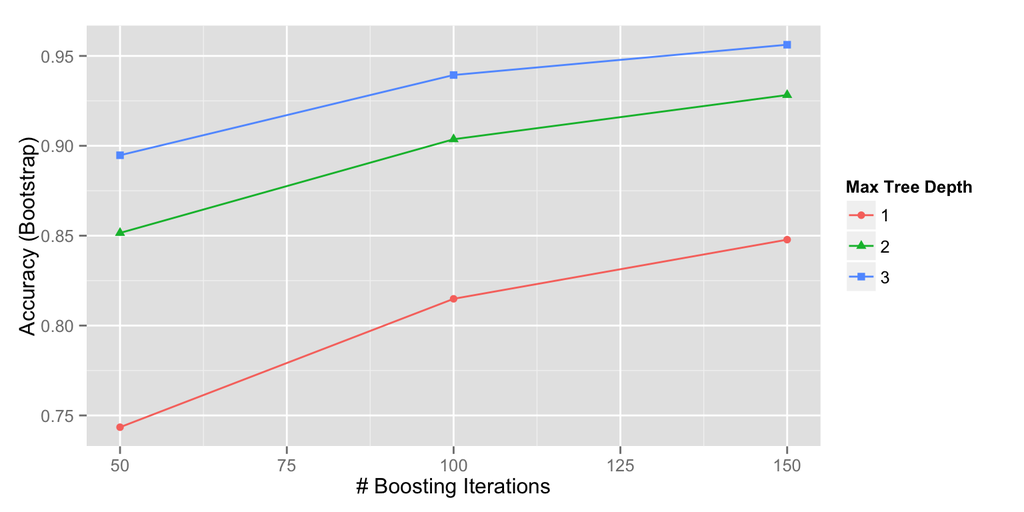

## 3.2) Boosted tree model with cross validation (method=“gbm”- 10-fold)

The same model was run with cross validation: 10 folds and 10 runs were used (trainControl object).  
I did not observe any significant performance gain on the test set with cross validation - performance are comparable with 3.1).  
The model accuracy is 0.9568, with a performance summary below (confusion matrix on test set):

```
## Confusion Matrix and Statistics
##
##           Reference
## Prediction    A    B    C    D    E
##          A 1370   13    6    4    2
##          B   31  878   40    0    0
##          C    0   26  811   14    4
##          D    1    6   30  760    7
##          E    0   11    8    9  873
##
## Overall Statistics
##
##                Accuracy : 0.9568
##                  95% CI : (0.9507, 0.9623)
##     No Information Rate : 0.2859
##     P-Value [Acc > NIR] : < 2.2e-16
##
##                   Kappa : 0.9453
##  Mcnemar's Test P-Value : 2.638e-06
##
## Statistics by Class:
##
##                      Class: A Class: B Class: C Class: D Class: E
## Sensitivity            0.9772   0.9400   0.9061   0.9657   0.9853
## Specificity            0.9929   0.9821   0.9890   0.9893   0.9930
## Pos Pred Value         0.9821   0.9252   0.9485   0.9453   0.9689
## Neg Pred Value         0.9909   0.9858   0.9793   0.9934   0.9968
## Prevalence             0.2859   0.1905   0.1825   0.1605   0.1807
## Detection Rate         0.2794   0.1790   0.1654   0.1550   0.1780
## Detection Prevalence   0.2845   0.1935   0.1743   0.1639   0.1837
## Balanced Accuracy      0.9850   0.9611   0.9476   0.9775   0.9892
```

It seems cross validation did not improve the model performance on the test set in our specific scenario (hypothesis: glm already use boosting/sampling on the training set - cross validation might not improve the model in this case ).  
Here is the model accuracy per number of boosiing iteration and max tree depth.

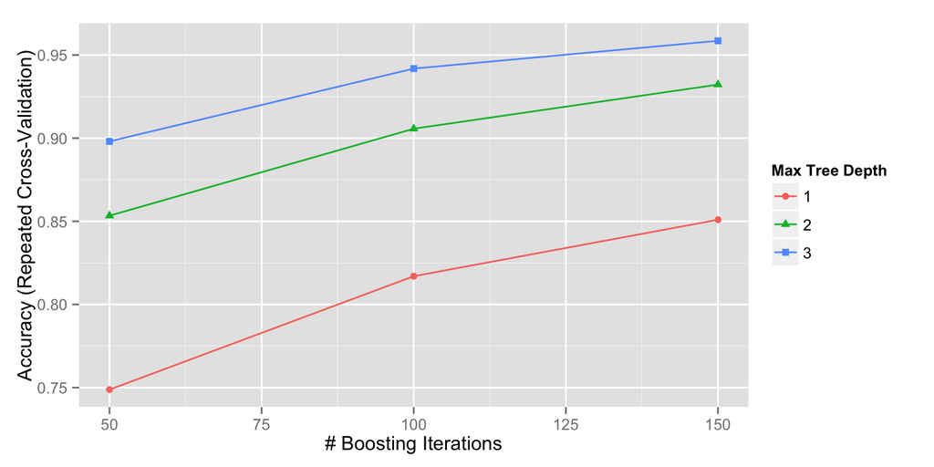

## 3.3) Random forest (method=“rf”)

Random forest is the best performing model, however it needs a significant computing time (2.5h on 4 cores CPU compared with less than 30min for other models).  
The model accurcy is 0.9923, with a performance summary below (confusion matrix on test set):

```
## Confusion Matrix and Statistics
##
##           Reference
## Prediction    A    B    C    D    E
##          A 1394    0    0    0    1
##          B    4  935   10    0    0
##          C    0    6  848    1    0
##          D    0    1   10  791    2
##          E    0    0    0    3  898
##
## Overall Statistics
##
##                Accuracy : 0.9923
##                  95% CI : (0.9894, 0.9945)
##     No Information Rate : 0.2851
##     P-Value [Acc > NIR] : < 2.2e-16
##
##                   Kappa : 0.9902
##  Mcnemar's Test P-Value : NA
##
## Statistics by Class:
##
##                      Class: A Class: B Class: C Class: D Class: E
## Sensitivity            0.9971   0.9926   0.9770   0.9950   0.9967
## Specificity            0.9997   0.9965   0.9983   0.9968   0.9993
## Pos Pred Value         0.9993   0.9852   0.9918   0.9838   0.9967
## Neg Pred Value         0.9989   0.9982   0.9951   0.9990   0.9993
## Prevalence             0.2851   0.1921   0.1770   0.1621   0.1837
## Detection Rate         0.2843   0.1907   0.1729   0.1613   0.1831
## Detection Prevalence   0.2845   0.1935   0.1743   0.1639   0.1837
## Balanced Accuracy      0.9984   0.9945   0.9876   0.9959   0.9980
```

Here is the model accuracy per number of randomly selected features. It seems 22 features are optimal for better accuracy.

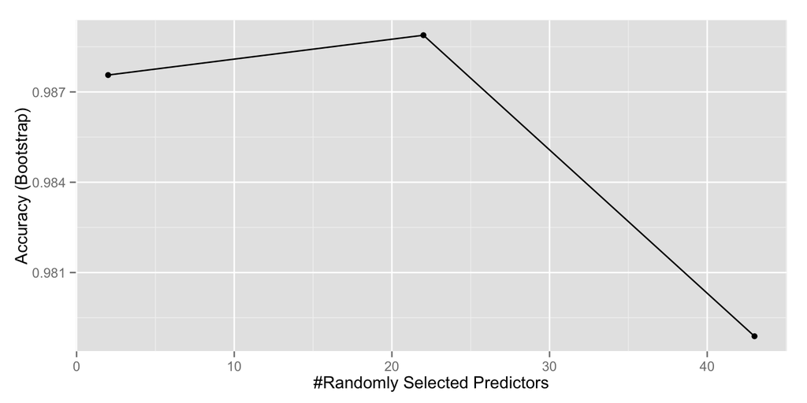

# 4) Conclusion

Feature selection is key in this process (removing timestamp and NA columns)

The boosted tree model accuracy is not improved when using cross validation (overall performance was comparable with or without cross validation).

The best performance was achieved with the random forest algorithm - without cross validation (not experimented because of lack of time). This model reached 100% success on the project submission (20 correct answers).

Parallel processing was important when using the random forest algorithm (as it took already 2.5h on a 4 core CPU)